# homework1

Yaxue Guo

8/27/2018

*This homework is due September 5th 6pm.*

(This set of exercise is mostly taken from R for Data Science by Garrett Grolemund and Hadley Wickham.)

# Exercise 1

1. What’s gone wrong with this code? Why are the points not blue?

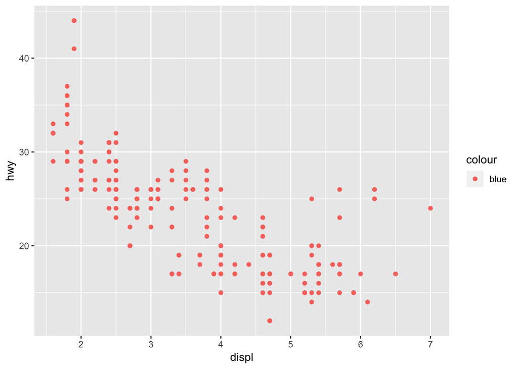

   ```r
   library(ggplot2)
   ggplot(data = mpg) +
     geom_point(mapping = aes(x = displ, y = hwy, color = "blue"))
   ```

   Answer:

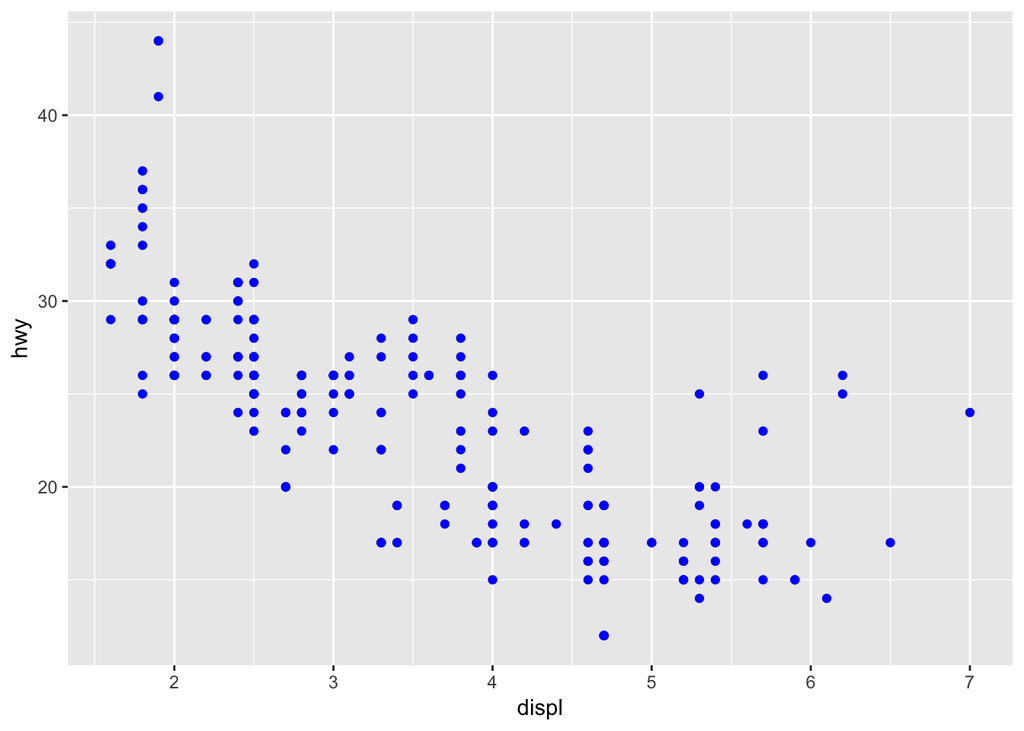

   ```r
   library(ggplot2)
   ggplot(data = mpg) +
     geom_point(mapping = aes(x = displ, y = hwy), color = "blue")
   ```

   - Color here doesn’t convey information of a variable but only changes the appearance of the plot, so it should be outside the mapping argument.
2. Which variables in `mpg` are categorical? Which variables are continuous? (Hint: type `?mpg` to read the documentation for the dataset). How can you see this information when you run `mpg`?

   Answer:

   ```r
   mpg
   ```

   ```
   ## # A tibble: 234 x 11
   ##    manufacturer model displ  year   cyl trans drv     cty   hwy fl    cla…
   ##    <chr>        <chr> <dbl> <int> <int> <chr> <chr> <int> <int> <chr> <ch>
   ##  1 audi         a4      1.8  1999     4 auto… f        18    29 p     com…
   ##  2 audi         a4      1.8  1999     4 manu… f        21    29 p     com…
   ##  3 audi         a4      2    2008     4 manu… f        20    31 p     com…
   ##  4 audi         a4      2    2008     4 auto… f        21    30 p     com…
   ##  5 audi         a4      2.8  1999     6 auto… f        16    26 p     com…
   ##  6 audi         a4      2.8  1999     6 manu… f        18    26 p     com…
   ##  7 audi         a4      3.1  2008     6 auto… f        18    27 p     com…
   ##  8 audi         a4 q…   1.8  1999     4 manu… 4        18    26 p     com…
   ##  9 audi         a4 q…   1.8  1999     4 auto… 4        16    25 p     com…
   ## 10 audi         a4 q…   2    2008     4 manu… 4        20    28 p     com…
   ## # ... with 224 more rows
   ```

   - Categorical: manufacturer, model, trans, drv, fl, class
   - Continuous: displ, year, cyl, cty, hwy
3. Map a continuous variable to `color`, `size`, and `shape`. How do these aesthetics behave differently for categorical vs. continuous variables?

   Answer:

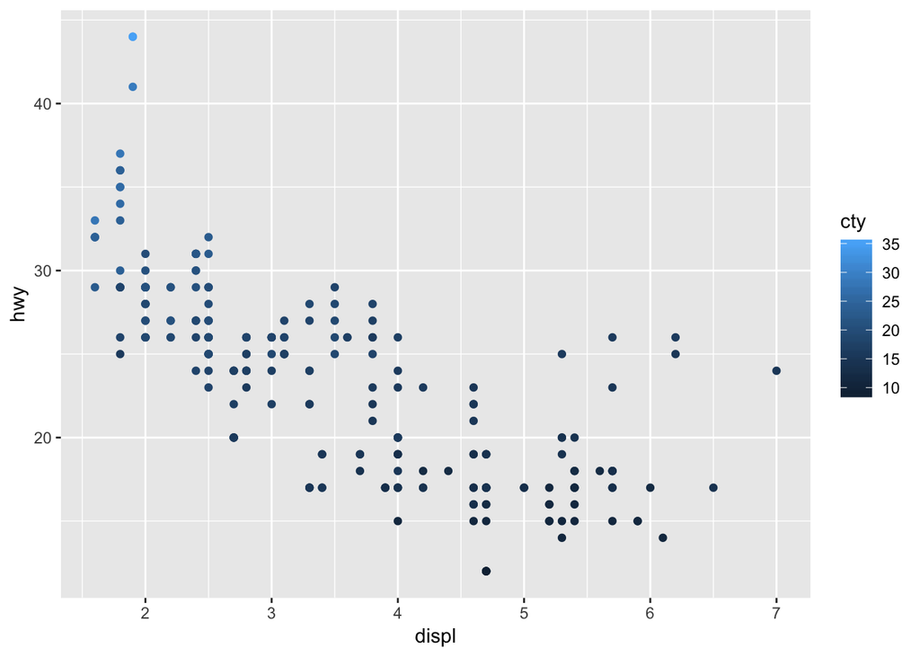

   ```r
   ggplot( data = mpg) + geom_point(mapping = aes(x = displ, y = hwy, color = cty))
   ```

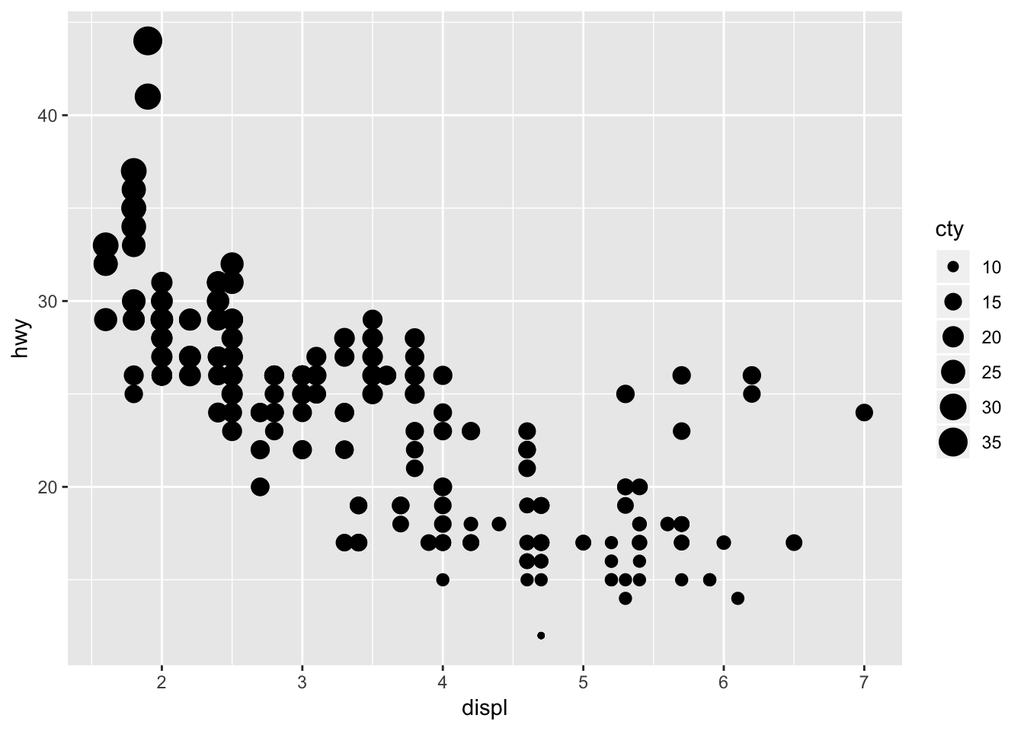

   ```r
   ggplot( data = mpg) + geom_point(mapping = aes(x = displ, y = hwy, size = cty))
   ```

   - When mapped to size, aesthetics assign different sizes of dots according to the value to cty. But the legend only shows representative ones instead of a continuous legend as mapping to color.
   - Got an error message that “A continues variable cannot be mapped to shape”. I think it is because that there are only limited kinds of shapes while a continuous variable could be unlimited.
4. What happens if you map the same variable to multiple aesthetics?

   Answer:

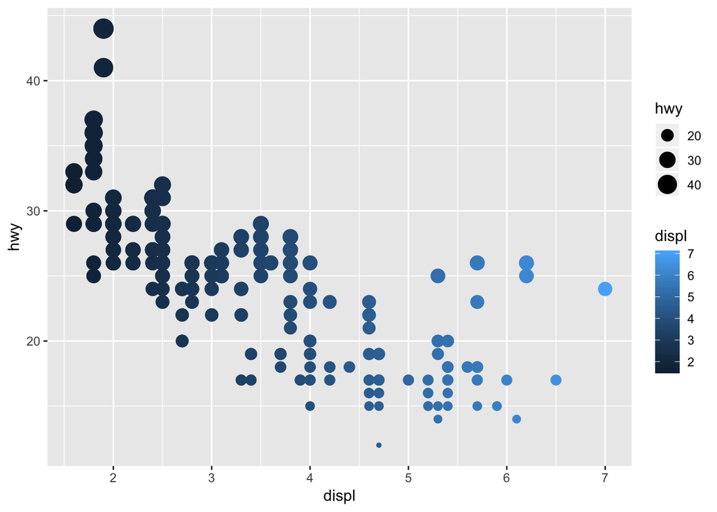

   ```r
   ggplot( data = mpg) + geom_point(mapping = aes(x = displ, y = hwy, color = displ, size = hwy))
   ```

   In the plot above, hwy is mapped to y axis as well as size, and displ is mapped to both x axis and color, which is unnecessary because we have already had idea of hwy and displ values through x-y coordinate thus do not need extra color or size information to facilitate understanding.
5. What does the `stroke` aesthetic do? What shapes does it work with? (Hint: use `?geom_point`)

   Answer:

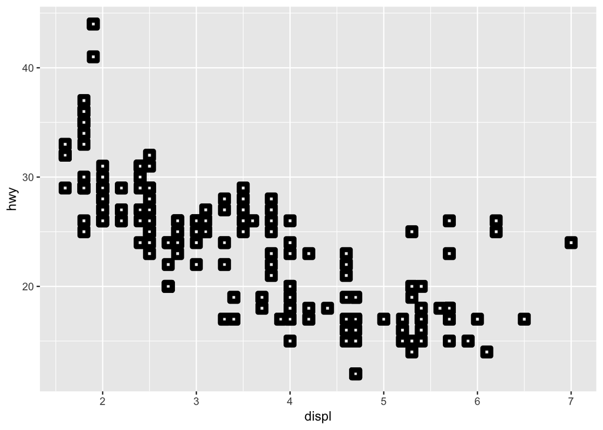

   ```r
   ggplot(data = mpg) + geom_point(mapping = aes(x = displ, y = hwy), shape = 22, stroke = 3)
   ```

   `stroke’ can change the border of shapes.The bigger the stroke is, the wider the border is.
6. What happens if you map an aesthetic to something other than a variable name, like `aes(colour = displ < 5)`?

   Answer:

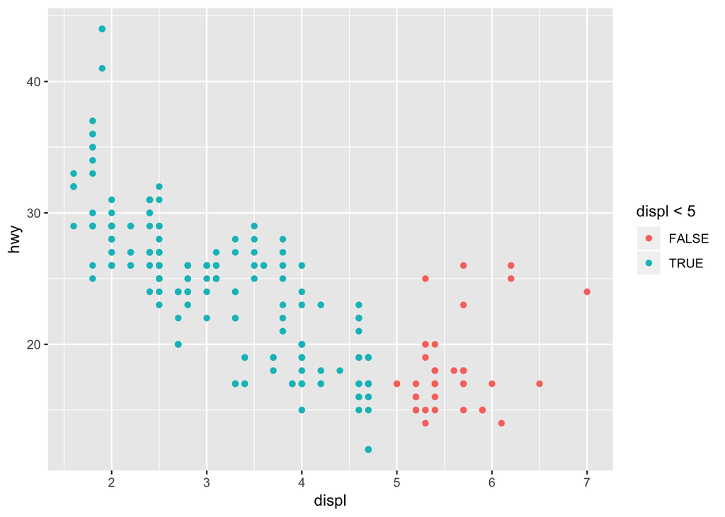

   ```r
   ggplot(data = mpg) + geom_point(mapping = aes(x = displ, y = hwy, color = displ < 5))
   ```

   The color will follow true or false of the condition when you map the aesthetic.

# Exercise 2

1. What do the empty cells in plot with `facet_grid(drv ~ cyl)` mean? How do they relate to this plot?

   ```r
   ggplot(data = mpg) +
     geom_point(mapping = aes(x = drv, y = cyl))
   ```

   Answer:

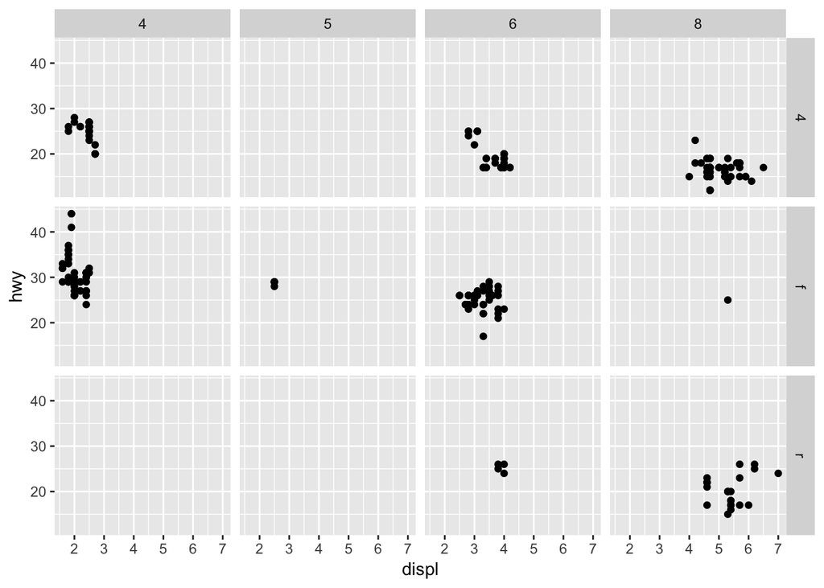

   ```r
   ggplot(data = mpg) +
     geom_point(mapping = aes(x = displ, y = hwy)) +
     facet_grid(drv ~ cyl)
   ```

   ```r
   ggplot(data = mpg) +
     geom_point(mapping = aes(x = displ, y = hwy)) +
     facet_grid(drv ~ .)

   ggplot(data = mpg) +
     geom_point(mapping = aes(x = displ, y = hwy)) +
     facet_grid(. ~ cyl)
   ```

   ```r
   ggplot(data = mpg) +
     geom_point(mapping = aes(x = displ, y = hwy)) +
     facet_wrap(~ class, nrow = 2)
   ```

   What are the advantages to using faceting instead of the colour aesthetic? What are the disadvantages? How might the balance change if you had a larger dataset?

   Answer:
   - Advantage: Easier and clearer to tell categories. Less data points in each plot. Better for color-blind people.Easier to tell similarity and difference of patterns between different categories.
   - Disadvantage: Could occupy too much space if there is many categories, especially when empty cells are at a large portion, this way is space-wasting. Harder to compare individual points’ location and the relationship.
   - If I have a larger dataset, I would prefer using facet plot first since there would be less overlapping. But I will also use color, size or alpha to facilitate the visualiztion as an addition if there aren’t too many categories.